# Risk Factor Analysis

## Outcome Variable

**Outcome Variable:** ever_sstunted

## Predictor Variables

**Intervention Variable:** nhh

**Adjustment Set:**

unadjusted

## Stratifying Variables

The analysis was stratified on these variable(s):

- agecat
- studyid
- country

## Data Summary

| agecat | studyid | country | nhh | ever_sstunted | n_cell | n | outcome_variable |
| --- | --- | --- | --- | --- | --- | --- | --- |
| 0-24 months | ki1000108-IRC | INDIA | 3 or less | 0 | 47 | 410 | ever_sstunted |
| 0-24 months | ki1000108-IRC | INDIA | 3 or less | 1 | 11 | 410 | ever_sstunted |
| 0-24 months | ki1000108-IRC | INDIA | 4-5 | 0 | 114 | 410 | ever_sstunted |
| 0-24 months | ki1000108-IRC | INDIA | 4-5 | 1 | 44 | 410 | ever_sstunted |
| 0-24 months | ki1000108-IRC | INDIA | 6-7 | 0 | 80 | 410 | ever_sstunted |
| 0-24 months | ki1000108-IRC | INDIA | 6-7 | 1 | 27 | 410 | ever_sstunted |
| 0-24 months | ki1000108-IRC | INDIA | 8+ | 0 | 67 | 410 | ever_sstunted |
| 0-24 months | ki1000108-IRC | INDIA | 8+ | 1 | 20 | 410 | ever_sstunted |
| 0-24 months | ki1000304b-SAS-FoodSuppl | INDIA | 3 or less | 0 | 28 | 418 | ever_sstunted |
| 0-24 months | ki1000304b-SAS-FoodSuppl | INDIA | 3 or less | 1 | 10 | 418 | ever_sstunted |
| 0-24 months | ki1000304b-SAS-FoodSuppl | INDIA | 4-5 | 0 | 97 | 418 | ever_sstunted |
| 0-24 months | ki1000304b-SAS-FoodSuppl | INDIA | 4-5 | 1 | 86 | 418 | ever_sstunted |
| 0-24 months | ki1000304b-SAS-FoodSuppl | INDIA | 6-7 | 0 | 58 | 418 | ever_sstunted |
| 0-24 months | ki1000304b-SAS-FoodSuppl | INDIA | 6-7 | 1 | 69 | 418 | ever_sstunted |
| 0-24 months | ki1000304b-SAS-FoodSuppl | INDIA | 8+ | 0 | 34 | 418 | ever_sstunted |
| 0-24 months | ki1000304b-SAS-FoodSuppl | INDIA | 8+ | 1 | 36 | 418 | ever_sstunted |
| 0-24 months | ki1017093-NIH-Birth | BANGLADESH | 3 or less | 0 | 87 | 629 | ever_sstunted |
| 0-24 months | ki1017093-NIH-Birth | BANGLADESH | 3 or less | 1 | 30 | 629 | ever_sstunted |
| 0-24 months | ki1017093-NIH-Birth | BANGLADESH | 4-5 | 0 | 172 | 629 | ever_sstunted |
| 0-24 months | ki1017093-NIH-Birth | BANGLADESH | 4-5 | 1 | 92 | 629 | ever_sstunted |
| 0-24 months | ki1017093-NIH-Birth | BANGLADESH | 6-7 | 0 | 98 | 629 | ever_sstunted |
| 0-24 months | ki1017093-NIH-Birth | BANGLADESH | 6-7 | 1 | 44 | 629 | ever_sstunted |
| 0-24 months | ki1017093-NIH-Birth | BANGLADESH | 8+ | 0 | 76 | 629 | ever_sstunted |
| 0-24 months | ki1017093-NIH-Birth | BANGLADESH | 8+ | 1 | 30 | 629 | ever_sstunted |
| 0-24 months | ki1017093b-PROVIDE | BANGLADESH | 3 or less | 0 | 117 | 700 | ever_sstunted |
| 0-24 months | ki1017093b-PROVIDE | BANGLADESH | 3 or less | 1 | 23 | 700 | ever_sstunted |
| 0-24 months | ki1017093b-PROVIDE | BANGLADESH | 4-5 | 0 | 280 | 700 | ever_sstunted |
| 0-24 months | ki1017093b-PROVIDE | BANGLADESH | 4-5 | 1 | 42 | 700 | ever_sstunted |
| 0-24 months | ki1017093b-PROVIDE | BANGLADESH | 6-7 | 0 | 135 | 700 | ever_sstunted |
| 0-24 months | ki1017093b-PROVIDE | BANGLADESH | 6-7 | 1 | 16 | 700 | ever_sstunted |

[output cut: 66 more lines]

The following strata were considered:

- agecat: 0-24 months, studyid: ki1000108-IRC, country: INDIA
- agecat: 0-24 months, studyid: ki1000304b-SAS-FoodSuppl, country: INDIA
- agecat: 0-24 months, studyid: ki1017093-NIH-Birth, country: BANGLADESH
- agecat: 0-24 months, studyid: ki1017093b-PROVIDE, country: BANGLADESH
- agecat: 0-24 months, studyid: ki1017093c-NIH-Crypto, country: BANGLADESH
- agecat: 0-24 months, studyid: ki1148112-LCNI-5, country: MALAWI
- agecat: 0-6 months, studyid: ki1000108-IRC, country: INDIA
- agecat: 0-6 months, studyid: ki1000304b-SAS-FoodSuppl, country: INDIA
- agecat: 0-6 months, studyid: ki1017093-NIH-Birth, country: BANGLADESH
- agecat: 0-6 months, studyid: ki1017093b-PROVIDE, country: BANGLADESH
- agecat: 0-6 months, studyid: ki1017093c-NIH-Crypto, country: BANGLADESH
- agecat: 0-6 months, studyid: ki1148112-LCNI-5, country: MALAWI

### Dropped Strata

Some strata were dropped due to rare outcomes:

- agecat: 0-6 months, studyid: ki1000304b-SAS-FoodSuppl, country: INDIA
- agecat: 0-6 months, studyid: ki1017093b-PROVIDE, country: BANGLADESH
- agecat: 0-6 months, studyid: ki1148112-LCNI-5, country: MALAWI

## Methods Detail

We’re interested in the causal parameters $E[Y_a]$ for all values of $a \in \mathcal{A}$. These parameters represent the mean outcome if, possibly contrary to fact, we intervened to set all units to have $A=a$. Under the randomization and positivity assumptions, these are identified by the statistical parameters $\psi_a=E_W[E_{Y|A,W}(Y|A=a,W)]$. In addition, we’re interested in the mean of $Y$, $E[Y]$ under no intervention (the observed mean). We will estimate these parameters by using SuperLearner to fit the relevant likelihood factors – $E_{Y|A,W}(Y|A=a,W)$ and $p(A=a|W)$, and then updating our likelihood fit using a joint TMLE.

For unadjusted analyses ($W=\{\}$), initial likelihoods were estimated using Lrnr_glm to estimate the simple $E(Y|A)$ and Lrnr_mean to estimate $p(A)$. For adjusted analyses, a small library containing Lrnr_glmnet, Lrnr_xgboost, and Lrnr_mean was used.

Having estimated these parameters, we will then use the delta method to estimate relative risks and attributable risks relative to a prespecified baseline level of $A$.

# Results Detail

## Results Plots

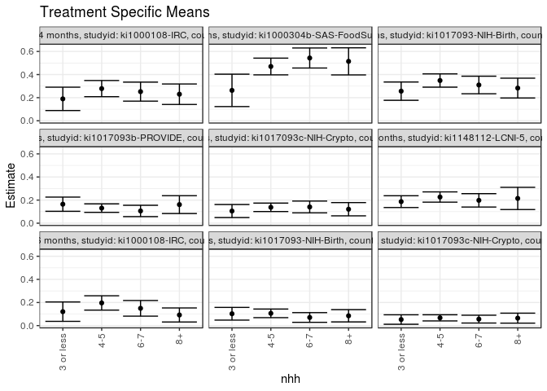

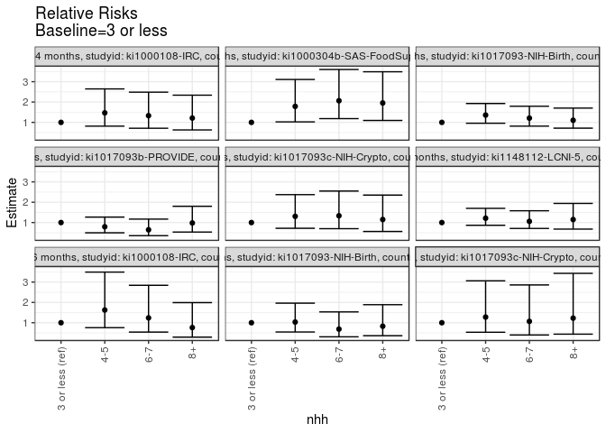

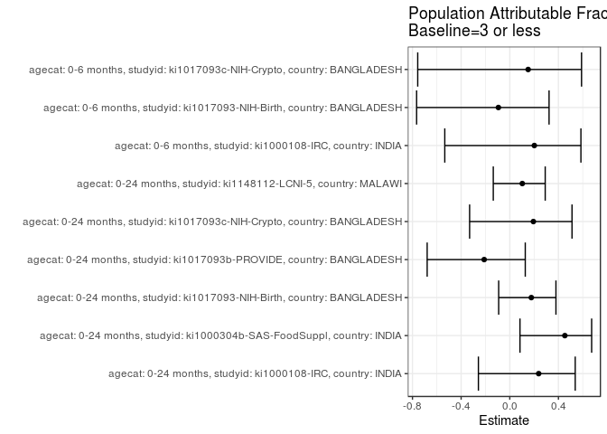

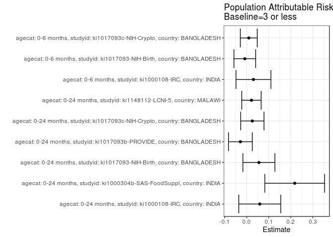

## Results Table

### Parameter: TSM

| agecat | studyid | country | intervention_level | baseline_level | estimate | ci_lower | ci_upper |
| --- | --- | --- | --- | --- | --- | --- | --- |
| 0-24 months | ki1000108-IRC | INDIA | 3 or less | NA | 0.1896552 | 0.0886412 | 0.2906692 |
| 0-24 months | ki1000108-IRC | INDIA | 4-5 | NA | 0.2784810 | 0.2085014 | 0.3484606 |
| 0-24 months | ki1000108-IRC | INDIA | 6-7 | NA | 0.2523364 | 0.1699360 | 0.3347369 |
| 0-24 months | ki1000108-IRC | INDIA | 8+ | NA | 0.2298851 | 0.1413629 | 0.3184072 |
| 0-24 months | ki1000304b-SAS-FoodSuppl | INDIA | 3 or less | NA | 0.2631579 | 0.1229825 | 0.4033333 |
| 0-24 months | ki1000304b-SAS-FoodSuppl | INDIA | 4-5 | NA | 0.4699454 | 0.3975473 | 0.5423434 |
| 0-24 months | ki1000304b-SAS-FoodSuppl | INDIA | 6-7 | NA | 0.5433071 | 0.4565707 | 0.6300434 |
| 0-24 months | ki1000304b-SAS-FoodSuppl | INDIA | 8+ | NA | 0.5142857 | 0.3970630 | 0.6315085 |
| 0-24 months | ki1017093-NIH-Birth | BANGLADESH | 3 or less | NA | 0.2564103 | 0.1772267 | 0.3355938 |
| 0-24 months | ki1017093-NIH-Birth | BANGLADESH | 4-5 | NA | 0.3484848 | 0.2909613 | 0.4060084 |
| 0-24 months | ki1017093-NIH-Birth | BANGLADESH | 6-7 | NA | 0.3098592 | 0.2337389 | 0.3859794 |
| 0-24 months | ki1017093-NIH-Birth | BANGLADESH | 8+ | NA | 0.2830189 | 0.1971962 | 0.3688416 |
| 0-24 months | ki1017093b-PROVIDE | BANGLADESH | 3 or less | NA | 0.1642857 | 0.1028638 | 0.2257076 |
| 0-24 months | ki1017093b-PROVIDE | BANGLADESH | 4-5 | NA | 0.1304348 | 0.0936237 | 0.1672458 |
| 0-24 months | ki1017093b-PROVIDE | BANGLADESH | 6-7 | NA | 0.1059603 | 0.0568333 | 0.1550872 |
| 0-24 months | ki1017093b-PROVIDE | BANGLADESH | 8+ | NA | 0.1609195 | 0.0836506 | 0.2381885 |
| 0-24 months | ki1017093c-NIH-Crypto | BANGLADESH | 3 or less | NA | 0.1052632 | 0.0488905 | 0.1616358 |
| 0-24 months | ki1017093c-NIH-Crypto | BANGLADESH | 4-5 | NA | 0.1374269 | 0.1009132 | 0.1739406 |
| 0-24 months | ki1017093c-NIH-Crypto | BANGLADESH | 6-7 | NA | 0.1404494 | 0.0893730 | 0.1915259 |
| 0-24 months | ki1017093c-NIH-Crypto | BANGLADESH | 8+ | NA | 0.1209677 | 0.0635348 | 0.1784007 |
| 0-24 months | ki1148112-LCNI-5 | MALAWI | 3 or less | NA | 0.1866667 | 0.1357230 | 0.2376104 |
| 0-24 months | ki1148112-LCNI-5 | MALAWI | 4-5 | NA | 0.2264706 | 0.1819543 | 0.2709869 |
| 0-24 months | ki1148112-LCNI-5 | MALAWI | 6-7 | NA | 0.1978022 | 0.1398947 | 0.2557097 |
| 0-24 months | ki1148112-LCNI-5 | MALAWI | 8+ | NA | 0.2142857 | 0.1181037 | 0.3104677 |
| 0-6 months | ki1000108-IRC | INDIA | 3 or less | NA | 0.1206897 | 0.0367494 | 0.2046299 |
| 0-6 months | ki1000108-IRC | INDIA | 4-5 | NA | 0.1962025 | 0.1342049 | 0.2582002 |
| 0-6 months | ki1000108-IRC | INDIA | 6-7 | NA | 0.1495327 | 0.0818803 | 0.2171851 |
| 0-6 months | ki1000108-IRC | INDIA | 8+ | NA | 0.0919540 | 0.0311604 | 0.1527477 |
| 0-6 months | ki1017093-NIH-Birth | BANGLADESH | 3 or less | NA | 0.1025641 | 0.0475467 | 0.1575815 |
| 0-6 months | ki1017093-NIH-Birth | BANGLADESH | 4-5 | NA | 0.1060606 | 0.0688880 | 0.1432332 |
| 0-6 months | ki1017093-NIH-Birth | BANGLADESH | 6-7 | NA | 0.0704225 | 0.0283064 | 0.1125386 |
| 0-6 months | ki1017093-NIH-Birth | BANGLADESH | 8+ | NA | 0.0849057 | 0.0317999 | 0.1380115 |
| 0-6 months | ki1017093c-NIH-Crypto | BANGLADESH | 3 or less | NA | 0.0526316 | 0.0116145 | 0.0936487 |
| 0-6 months | ki1017093c-NIH-Crypto | BANGLADESH | 4-5 | NA | 0.0672515 | 0.0406898 | 0.0938131 |
| 0-6 months | ki1017093c-NIH-Crypto | BANGLADESH | 6-7 | NA | 0.0561798 | 0.0223297 | 0.0900298 |
| 0-6 months | ki1017093c-NIH-Crypto | BANGLADESH | 8+ | NA | 0.0645161 | 0.0212472 | 0.1077851 |

### Parameter: E(Y)

| agecat | studyid | country | intervention_level | baseline_level | estimate | ci_lower | ci_upper |
| --- | --- | --- | --- | --- | --- | --- | --- |
| 0-24 months | ki1000108-IRC | INDIA | NA | NA | 0.2487805 | 0.2068840 | 0.2906770 |
| 0-24 months | ki1000304b-SAS-FoodSuppl | INDIA | NA | NA | 0.4808612 | 0.4329065 | 0.5288160 |
| 0-24 months | ki1017093-NIH-Birth | BANGLADESH | NA | NA | 0.3116057 | 0.2753823 | 0.3478292 |
| 0-24 months | ki1017093b-PROVIDE | BANGLADESH | NA | NA | 0.1357143 | 0.1103250 | 0.1611036 |
| 0-24 months | ki1017093c-NIH-Crypto | BANGLADESH | NA | NA | 0.1306069 | 0.1066024 | 0.1546113 |
| 0-24 months | ki1148112-LCNI-5 | MALAWI | NA | NA | 0.2080783 | 0.1802263 | 0.2359304 |
| 0-6 months | ki1000108-IRC | INDIA | NA | NA | 0.1512195 | 0.1164988 | 0.1859402 |
| 0-6 months | ki1017093-NIH-Birth | BANGLADESH | NA | NA | 0.0937997 | 0.0709973 | 0.1166021 |
| 0-6 months | ki1017093c-NIH-Crypto | BANGLADESH | NA | NA | 0.0620053 | 0.0448256 | 0.0791849 |

### Parameter: RR

| agecat | studyid | country | intervention_level | baseline_level | estimate | ci_lower | ci_upper |
| --- | --- | --- | --- | --- | --- | --- | --- |
| 0-24 months | ki1000108-IRC | INDIA | 3 or less | 3 or less | 1.0000000 | 1.0000000 | 1.000000 |
| 0-24 months | ki1000108-IRC | INDIA | 4-5 | 3 or less | 1.4683544 | 0.8148260 | 2.646043 |
| 0-24 months | ki1000108-IRC | INDIA | 6-7 | 3 or less | 1.3305013 | 0.7123408 | 2.485094 |
| 0-24 months | ki1000108-IRC | INDIA | 8+ | 3 or less | 1.2121212 | 0.6282185 | 2.338737 |
| 0-24 months | ki1000304b-SAS-FoodSuppl | INDIA | 3 or less | 3 or less | 1.0000000 | 1.0000000 | 1.000000 |
| 0-24 months | ki1000304b-SAS-FoodSuppl | INDIA | 4-5 | 3 or less | 1.7857923 | 1.0256896 | 3.109181 |
| 0-24 months | ki1000304b-SAS-FoodSuppl | INDIA | 6-7 | 3 or less | 2.0645669 | 1.1839363 | 3.600225 |
| 0-24 months | ki1000304b-SAS-FoodSuppl | INDIA | 8+ | 3 or less | 1.9542857 | 1.0948744 | 3.488284 |
| 0-24 months | ki1017093-NIH-Birth | BANGLADESH | 3 or less | 3 or less | 1.0000000 | 1.0000000 | 1.000000 |
| 0-24 months | ki1017093-NIH-Birth | BANGLADESH | 4-5 | 3 or less | 1.3590909 | 0.9575784 | 1.928958 |
| 0-24 months | ki1017093-NIH-Birth | BANGLADESH | 6-7 | 3 or less | 1.2084507 | 0.8144272 | 1.793105 |
| 0-24 months | ki1017093-NIH-Birth | BANGLADESH | 8+ | 3 or less | 1.1037736 | 0.7160021 | 1.701554 |
| 0-24 months | ki1017093b-PROVIDE | BANGLADESH | 3 or less | 3 or less | 1.0000000 | 1.0000000 | 1.000000 |
| 0-24 months | ki1017093b-PROVIDE | BANGLADESH | 4-5 | 3 or less | 0.7939509 | 0.4970002 | 1.268325 |
| 0-24 months | ki1017093b-PROVIDE | BANGLADESH | 6-7 | 3 or less | 0.6449755 | 0.3555311 | 1.170062 |
| 0-24 months | ki1017093b-PROVIDE | BANGLADESH | 8+ | 3 or less | 0.9795102 | 0.5329847 | 1.800127 |
| 0-24 months | ki1017093c-NIH-Crypto | BANGLADESH | 3 or less | 3 or less | 1.0000000 | 1.0000000 | 1.000000 |
| 0-24 months | ki1017093c-NIH-Crypto | BANGLADESH | 4-5 | 3 or less | 1.3055555 | 0.7180629 | 2.373713 |
| 0-24 months | ki1017093c-NIH-Crypto | BANGLADESH | 6-7 | 3 or less | 1.3342697 | 0.6984022 | 2.549069 |
| 0-24 months | ki1017093c-NIH-Crypto | BANGLADESH | 8+ | 3 or less | 1.1491935 | 0.5617863 | 2.350797 |
| 0-24 months | ki1148112-LCNI-5 | MALAWI | 3 or less | 3 or less | 1.0000000 | 1.0000000 | 1.000000 |
| 0-24 months | ki1148112-LCNI-5 | MALAWI | 4-5 | 3 or less | 1.2132353 | 0.8667181 | 1.698291 |
| 0-24 months | ki1148112-LCNI-5 | MALAWI | 6-7 | 3 or less | 1.0596546 | 0.7101422 | 1.581187 |
| 0-24 months | ki1148112-LCNI-5 | MALAWI | 8+ | 3 or less | 1.1479592 | 0.6788731 | 1.941173 |
| 0-6 months | ki1000108-IRC | INDIA | 3 or less | 3 or less | 1.0000000 | 1.0000000 | 1.000000 |
| 0-6 months | ki1000108-IRC | INDIA | 4-5 | 3 or less | 1.6256781 | 0.7572995 | 3.489807 |
| 0-6 months | ki1000108-IRC | INDIA | 6-7 | 3 or less | 1.2389853 | 0.5404161 | 2.840561 |
| 0-6 months | ki1000108-IRC | INDIA | 8+ | 3 or less | 0.7619048 | 0.2918463 | 1.989057 |
| 0-6 months | ki1017093-NIH-Birth | BANGLADESH | 3 or less | 3 or less | 1.0000000 | 1.0000000 | 1.000000 |
| 0-6 months | ki1017093-NIH-Birth | BANGLADESH | 4-5 | 3 or less | 1.0340909 | 0.5448490 | 1.962643 |
| 0-6 months | ki1017093-NIH-Birth | BANGLADESH | 6-7 | 3 or less | 0.6866197 | 0.3074793 | 1.533263 |
| 0-6 months | ki1017093-NIH-Birth | BANGLADESH | 8+ | 3 or less | 0.8278302 | 0.3631514 | 1.887099 |
| 0-6 months | ki1017093c-NIH-Crypto | BANGLADESH | 3 or less | 3 or less | 1.0000000 | 1.0000000 | 1.000000 |
| 0-6 months | ki1017093c-NIH-Crypto | BANGLADESH | 4-5 | 3 or less | 1.2777778 | 0.5333533 | 3.061228 |
| 0-6 months | ki1017093c-NIH-Crypto | BANGLADESH | 6-7 | 3 or less | 1.0674157 | 0.3985813 | 2.858579 |
| 0-6 months | ki1017093c-NIH-Crypto | BANGLADESH | 8+ | 3 or less | 1.2258064 | 0.4384209 | 3.427304 |

### Parameter: PAR

| agecat | studyid | country | intervention_level | baseline_level | estimate | ci_lower | ci_upper |
| --- | --- | --- | --- | --- | --- | --- | --- |
| 0-24 months | ki1000108-IRC | INDIA | 3 or less | NA | 0.0591253 | -0.0361229 | 0.1543735 |
| 0-24 months | ki1000304b-SAS-FoodSuppl | INDIA | 3 or less | NA | 0.2177033 | 0.0821444 | 0.3532623 |
| 0-24 months | ki1017093-NIH-Birth | BANGLADESH | 3 or less | NA | 0.0551955 | -0.0172587 | 0.1276496 |
| 0-24 months | ki1017093b-PROVIDE | BANGLADESH | 3 or less | NA | -0.0285714 | -0.0824992 | 0.0253564 |
| 0-24 months | ki1017093c-NIH-Crypto | BANGLADESH | 3 or less | NA | 0.0253437 | -0.0275544 | 0.0782418 |
| 0-24 months | ki1148112-LCNI-5 | MALAWI | 3 or less | NA | 0.0214117 | -0.0226512 | 0.0654746 |
| 0-6 months | ki1000108-IRC | INDIA | 3 or less | NA | 0.0305299 | -0.0485777 | 0.1096374 |
| 0-6 months | ki1017093-NIH-Birth | BANGLADESH | 3 or less | NA | -0.0087644 | -0.0579660 | 0.0404372 |
| 0-6 months | ki1017093c-NIH-Crypto | BANGLADESH | 3 or less | NA | 0.0093737 | -0.0289863 | 0.0477337 |

### Parameter: PAF

| agecat | studyid | country | intervention_level | baseline_level | estimate | ci_lower | ci_upper |
| --- | --- | --- | --- | --- | --- | --- | --- |
| 0-24 months | ki1000108-IRC | INDIA | 3 or less | NA | 0.2376606 | -0.2579630 | 0.5380139 |
| 0-24 months | ki1000304b-SAS-FoodSuppl | INDIA | 3 or less | NA | 0.4527363 | 0.0838811 | 0.6730800 |
| 0-24 months | ki1017093-NIH-Birth | BANGLADESH | 3 or less | NA | 0.1771324 | -0.0912550 | 0.3795116 |
| 0-24 months | ki1017093b-PROVIDE | BANGLADESH | 3 or less | NA | -0.2105263 | -0.6791882 | 0.1273319 |
| 0-24 months | ki1017093c-NIH-Crypto | BANGLADESH | 3 or less | NA | 0.1940457 | -0.3301941 | 0.5116786 |
| 0-24 months | ki1148112-LCNI-5 | MALAWI | 3 or less | NA | 0.1029020 | -0.1356408 | 0.2913385 |
| 0-6 months | ki1000108-IRC | INDIA | 3 or less | NA | 0.2018910 | -0.5343522 | 0.5848554 |
| 0-6 months | ki1017093-NIH-Birth | BANGLADESH | 3 or less | NA | -0.0934376 | -0.7659589 | 0.3229707 |
| 0-6 months | ki1017093c-NIH-Crypto | BANGLADESH | 3 or less | NA | 0.1511758 | -0.7567274 | 0.5898610 |